# Union Status Project

## Overview

**Objective:** Build a model to predict whether a person will remain in a hypothetical trade union, the United Data Scientists Union (UDSU).

Assume a country with a major trade union for data scientists. Each member pays some dues amount to it each month and gets various benefits such as representation with employers and continuing education. You will be provided a dataset of 2,000 data scientist IDs by your instructor in Week 2. Each ID represents a data scientist who is a current or former member. Your dataset will contain several features such as:

- Whether the person is a member of the management
- Number of months the particular data scientist has been a member of the UDSU
- Financial dues paid (each month, and in total)
- Gender of the person
- Status (still a union member; or no longer a member)

## Import Data

```python
! pip install -q pyspark
! pip install -q findspark
```

```python
import findspark
from pyspark.sql import SparkSession
import pandas as pd

findspark.init()

spark = SparkSession\
    .builder\
    .appName("Spark SQL")\
    .getOrCreate()
```

```python
# create df from data
df = spark.read.option("header","true").csv('Alicia -TRAIN 1.csv', inferSchema=True)
# create a fallback copy of the original data
df_og = df.select("*")
df.printSchema()
```

```
root
 |-- ID: string (nullable = true)
 |-- gender: string (nullable = true)
 |-- Management: integer (nullable = true)
 |-- USAcitizen: string (nullable = true)
 |-- Married: string (nullable = true)
 |-- MonthsInUnion: integer (nullable = true)
 |-- ContinuingEd: string (nullable = true)
 |-- StateOfResidence: string (nullable = true)
 |-- Connectivity: string (nullable = true)
 |-- FeatureA: string (nullable = true)
 |-- FeatureB: string (nullable = true)
 |-- FeatureC: string (nullable = true)
 |-- FeatureD: string (nullable = true)
 |-- FeatureE: string (nullable = true)
 |-- FeatureF: string (nullable = true)
 |-- DuesFrequency: string (nullable = true)
 |-- PaperlessBilling: string (nullable = true)
 |-- PaymentMethod: string (nullable = true)
 |-- MonthlyDues: double (nullable = true)
 |-- TotalDues: string (nullable = true)
 |-- LeftUnion: string (nullable = true)
```

```python
# reference info
num_rows = df.count()
print("number of rows:",num_rows)
num_left = df.filter(df.LeftUnion=="Yes").count()
print("Total left union:",num_left,"=> Percent left union:", 100*num_left/num_rows)
num_stayed = df.filter(df.LeftUnion=="No").count()
print("Total stayed in union:",num_stayed,"=> Percent stayed in union:", 100*num_stayed/num_rows)
```

```
number of rows: 1999
Total left union: 533 => Percent left union: 26.663331665832917
Total stayed in union: 1466 => Percent stayed in union: 73.33666833416709
```

**Note: A model must achieve accuracy greater than 73.3% to be better than a blind guess that everyone stays in the union**

```python
# create dataframe to keep track of the accuracy of each model
accuracy_df = pd.DataFrame(columns=['model','accuracy'])
base_accuracy = pd.DataFrame(data={'model':['blind_guess'],'accuracy':[num_stayed/num_rows]})
accuracy_df = pd.concat([accuracy_df,base_accuracy])
accuracy_df
```

|  | model | accuracy |
| --- | --- | --- |
| 0 | blind_guess | 0.733367 |

## Initial Pre-Processing

```python
# Remove irrelivant leading text from ID column
from pyspark.sql.functions import regexp_replace
df = df.withColumn('ID',regexp_replace('ID','Alicia \d*-',''))
df.select('ID').show(5)
```

```
+-----+
|   ID|
+-----+
|16242|
|18805|
|14120|
|17845|
|13602|
+-----+
only showing top 5 rows
```

```python
# Count rows with null values
df.filter("ID is NULL or gender is NULL or Management is NULL or USAcitizen is NULL or Married is NULL or MonthsInUnion is NULL or ContinuingEd is NULL or StateOfResidence is NULL or Connectivity is NULL or FeatureA is NULL or FeatureB is NULL or FeatureC is NULL or FeatureE is NULL or FeatureF is NULL or DuesFrequency is NULL or PaperlessBilling is NULL or PaymentMethod is NULL or MonthlyDues is NULL or TotalDues is NULL or LeftUnion is NULL").count()
```

```
0
```

```python
from pyspark.sql.functions import trim
withBlanks=[]
for c in df.columns:
    col = df[c]
    if (df.filter(trim(col) == "")).count() != 0:
        withBlanks.append(c)
withBlanks
# TotalDues is the only column with blank cells
```

```
['TotalDues']
```

```python
# count rows with blank cells
df.filter(trim(df.TotalDues) == "").count()
```

```
6
```

```python
# remove rows with blank cells
df = df.filter(trim(df.TotalDues) != "")
```

```python
df.count()
```

```
1993
```

```python
# Sort the variables into type (categorical/numeric)
# Define names for groups of variables
idx = ['ID']
categorical = ['gender','Management','USAcitizen','Married','ContinuingEd','StateOfResidence','Connectivity','FeatureA',\
               'FeatureB','FeatureC','FeatureD','FeatureE','FeatureF','DuesFrequency','PaperlessBilling','PaymentMethod']
numeric = ['MonthsInUnion','MonthlyDues','TotalDues']
predictors = categorical + numeric
target = ['LeftUnion']
```

```python
for n in numeric:
    print(df.schema[n].dataType)
```

```
IntegerType()
DoubleType()
StringType()
```

```python
# Ensure all numerical variables are of a numeric data type
from pyspark.sql.functions import col
from pyspark.sql.types import ByteType,ShortType,IntegerType,LongType,FloatType,DoubleType,DecimalType
for n in numeric:
    if df.schema[n].dataType not in [ByteType(),ShortType(),IntegerType(),LongType(),FloatType(),DoubleType(),DecimalType()]:
        df = df.withColumn(n,col(n).cast(DoubleType()))
for n in numeric:
    print(df.schema[n].dataType)
```

```
IntegerType()
DoubleType()
DoubleType()
```

## Exploratory Data Analysis

### Univariate Plots

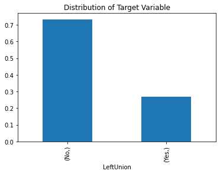

```python
import matplotlib.pyplot as plt
pd_df = df.toPandas()
plt.title("Distribution of Target Variable")
series = pd_df[target].value_counts()/len(pd_df)
series.plot(kind='bar')
plt.show()
```

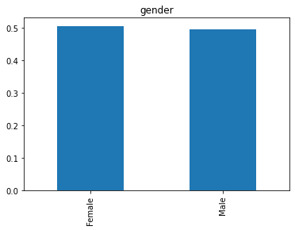

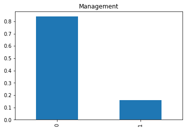

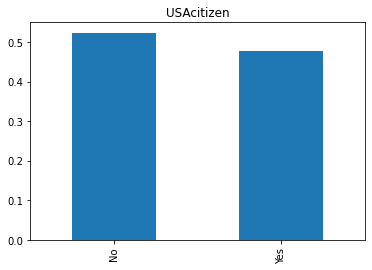

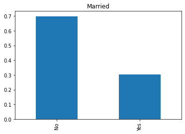

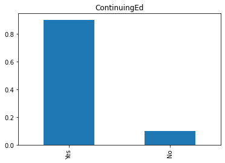

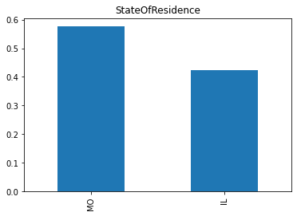

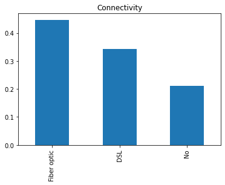

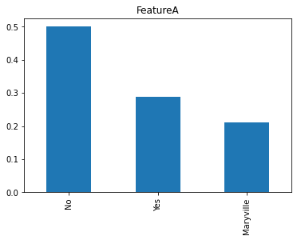

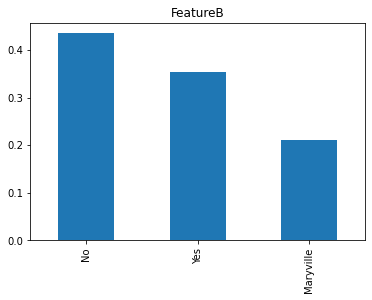

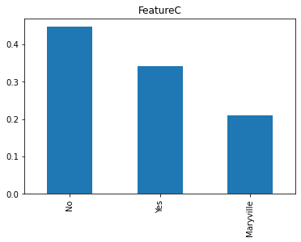

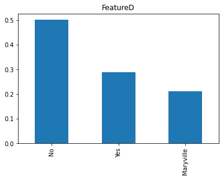

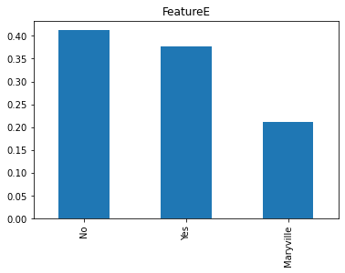

[4 more figures not shown]

```python
# bar charts for all categorical variables
for c in categorical:
    plt.title(c)
    series = pd_df[c].value_counts()/len(pd_df)
    series.plot(kind='bar')
    plt.show()
```

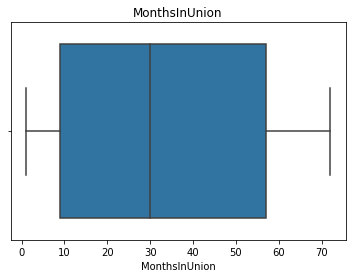

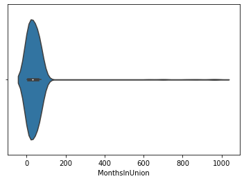

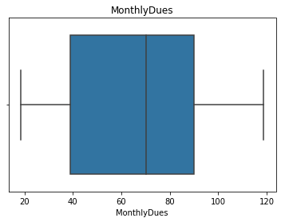

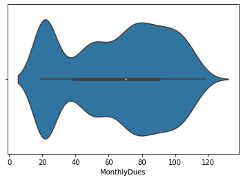

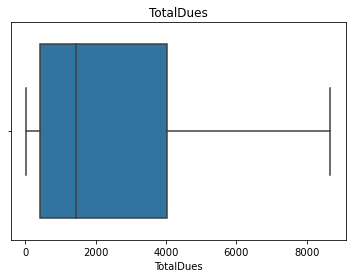

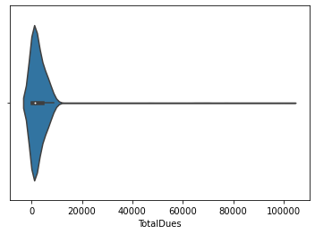

```python
# boxplots and violinplots for all numeric variables
import seaborn as sns
for n in numeric:
    plt.title(n)
    sns.boxplot(data=pd_df,x=n,showfliers=False)
    plt.show()
    sns.violinplot(data=pd_df,x=n,showfliers=False)
    plt.show()
```

### Multivariate Plots

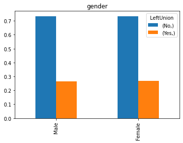

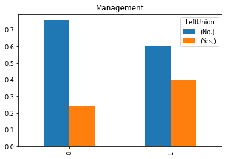

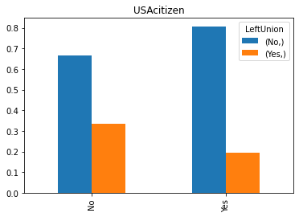

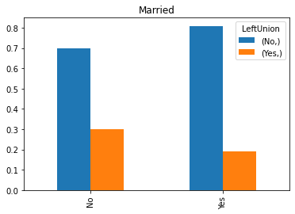

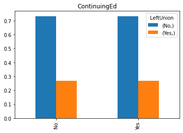

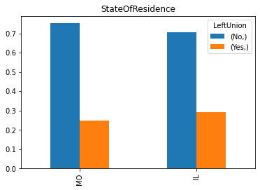

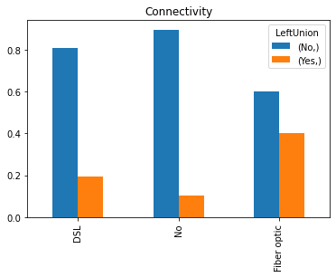

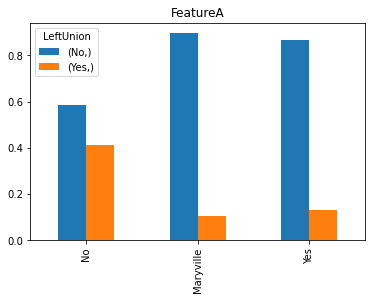

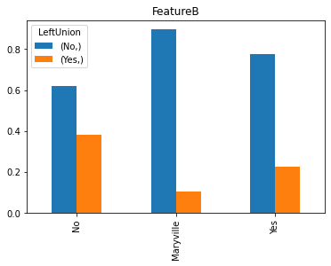

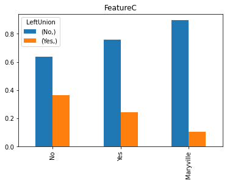

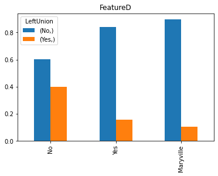

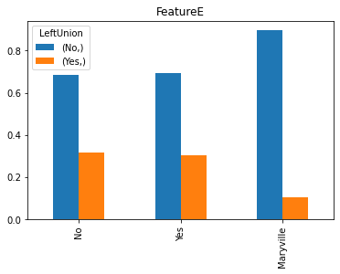

[4 more figures not shown]

```python
# grouped bar charts for bivariate distributions of the target with each categorical variable
for c in categorical:
    plot_df = pd.DataFrame(columns=pd.unique(pd_df[c]))
    for i in pd.unique(pd_df[c]):
        plot_df[i] = pd_df[pd_df[c]==i][target].value_counts()/len(pd_df[pd_df[c]==i])
    plot_df = plot_df.transpose()
    plot_df.plot(kind='bar')
    plt.title(c)
    plt.show()
```